# R Notebook

1. Load adult.data into a dataframe in R. Note that adult.data does not have column names in the first line so you need to set header=FALSE when you read the data then manually set the column names. Inspect the dataset using “str” and “summary” functions. What is the type of each variable in the dataset numeric/continuous or categorical/discrete? For each categorical variable explain whether it is nominal or ordinal.

```r
  install.packages("stringr", "tidyverse")
  library(stringr)
  library(tidyverse)
  adult_data <- read.csv("adult.data", header = FALSE, na.strings = " ?")
  colnames(adult_data) <- c("age", "workclass", "fnlwgt", "education", "education-num", "marital-status", "occupation", "relationship", "race", "sex", "capital-gain", "capital-loss", "hours-per-week", "native-country", "target")
  str(adult_data)
```

```
'data.frame':   32561 obs. of  15 variables:
 $ age           : int  39 50 38 53 28 37 49 52 31 42 ...
 $ workclass     : chr  " State-gov" " Self-emp-not-inc" " Private" " Private" ...
 $ fnlwgt        : int  77516 83311 215646 234721 338409 284582 160187 209642 45781 159449 ...
 $ education     : chr  " Bachelors" " Bachelors" " HS-grad" " 11th" ...
 $ education-num : int  13 13 9 7 13 14 5 9 14 13 ...
 $ marital-status: chr  " Never-married" " Married-civ-spouse" " Divorced" " Married-civ-spouse" ...
 $ occupation    : chr  " Adm-clerical" " Exec-managerial" " Handlers-cleaners" " Handlers-cleaners" ...
 $ relationship  : chr  " Not-in-family" " Husband" " Not-in-family" " Husband" ...
 $ race          : chr  " White" " White" " White" " Black" ...
 $ sex           : chr  " Male" " Male" " Male" " Male" ...
 $ capital-gain  : int  2174 0 0 0 0 0 0 0 14084 5178 ...
 $ capital-loss  : int  0 0 0 0 0 0 0 0 0 0 ...
 $ hours-per-week: int  40 13 40 40 40 40 16 45 50 40 ...
 $ native-country: chr  " United-States" " United-States" " United-States" " United-States" ...
 $ target        : chr  " <=50K" " <=50K" " <=50K" " <=50K" ...
```

```r
  summary(adult_data)
```

```
      age         workclass             fnlwgt         education         education-num   marital-status
 Min.   :17.00   Length:32561       Min.   :  12285   Length:32561       Min.   : 1.00   Length:32561
 1st Qu.:28.00   Class :character   1st Qu.: 117827   Class :character   1st Qu.: 9.00   Class :character
 Median :37.00   Mode  :character   Median : 178356   Mode  :character   Median :10.00   Mode  :character
 Mean   :38.58                      Mean   : 189778                      Mean   :10.08
 3rd Qu.:48.00                      3rd Qu.: 237051                      3rd Qu.:12.00
 Max.   :90.00                      Max.   :1484705                      Max.   :16.00
  occupation        relationship           race               sex             capital-gain    capital-loss
 Length:32561       Length:32561       Length:32561       Length:32561       Min.   :    0   Min.   :   0.0
 Class :character   Class :character   Class :character   Class :character   1st Qu.:    0   1st Qu.:   0.0
 Mode  :character   Mode  :character   Mode  :character   Mode  :character   Median :    0   Median :   0.0
                                                                             Mean   : 1078   Mean   :  87.3
                                                                             3rd Qu.:    0   3rd Qu.:   0.0
                                                                             Max.   :99999   Max.   :4356.0
 hours-per-week  native-country        target
 Min.   : 1.00   Length:32561       Length:32561
 1st Qu.:40.00   Class :character   Class :character
 Median :40.00   Mode  :character   Mode  :character
 Mean   :40.44
 3rd Qu.:45.00
 Max.   :99.00
```

```r
  # I had to do this for handling sparse data in native-country
  adult_data$`native-country` <- as.character(adult_data$`native-country`)
  adult_data$`native-country` <- str_trim(adult_data$`native-country`)
  adult_data$`native-country` <- as.factor(adult_data$`native-country`)
  adult_data <- adult_data |>
    mutate(`native-country` = fct_na_value_to_level(`native-country`, level = "United-States")) |>
    mutate(`native-country` = fct_collapse(`native-country`,
      North_America = c("United-States", "Mexico", "Canada", "Cuba", "Puerto-Rico", "Trinadad&Tobago", "Honduras", "Guatemala", "El-Salvador", "Haiti", "Jamaica", "Dominican-Republic", "Nicaragua"),
      South_America = c("Columbia", "Ecuador", "Peru"),
      Europe = c("England", "France", "Germany", "Greece", "Holand-Netherlands", "Hungary", "Ireland", "Italy", "Poland", "Portugal", "Scotland", "Yugoslavia"),
      Asia = c("Cambodia", "China", "Hong", "India", "Iran", "Japan", "Laos", "Outlying-US(Guam-USVI-etc)", "Philippines", "Taiwan", "Thailand", "Vietnam"),
      Other = "South"
    ))
```

The type of each variable is as follows:

- age: continuous
- workclass: categorical/nominal
- fnlwgt: continuous
- education: categorical/ordinal
- education-num: continuous
- marital-status: categorical/nominal
- occupation: categorical/nominal
- relationship: categorical/nominal
- race: categorical/nominal
- sex: categorical/nominal
- capital-gain: continuous
- capital-loss: continuous
- hours-per-week: continuous
- native-country: categorical/nominal
2. There are some missing values in this dataset represented as “ ?” (Note: there is a space before ?) . Make sure that all “ ?” are converted to NAs. You can do so by setting “na.strings” parameters in “read.csv” to “ ?”
- Done in the code block for question 1 above.
3. Set the random seed, and split the data to train/test. Use 80% of samples for training and the remaining 20% for testing. You can use “sample” (similar to what we did in slide 37 of week 6 lecture but you need to adjust1000 and 900 to the number of observations in your dataset and the size of the sample) or alternatively, you can use “createDataPartition” method from caret package.

```r
  install.packages("caret")
  library(caret)
  set.seed(1234)
  train_index <- createDataPartition(adult_data$target, p = .8, list = FALSE, times = 1)
  adult_train <- adult_data[train_index,]
  adult_test <- adult_data[-train_index,]
```

4. Read the section on “Handling Missing Data” in chapter 13 of the textbook Machine Learning with R. Find which columns/variables in the train and test set have missing values. Then decide about how you want to impute the missing values in these columns. Explain why you chose this imputation approach.

```r
  colSums(is.na(adult_data))
```

```
           age      workclass         fnlwgt      education  education-num marital-status     occupation   relationship
             0           1836              0              0              0              0           1843              0
          race            sex   capital-gain   capital-loss hours-per-week native-country         target
             0              0              0              0              0              0              0
```

```r
  adult_train <- adult_train |>
    mutate(
      `native-country_mvi` = if_else(is.na(`native-country`), 1, 0),
      `native-country` = if_else(is.na(`native-country`), 'United-States', `native-country`),
      occupation_mvi = if_else(is.na(occupation), 1, 0),
      occupation = if_else(is.na(occupation), 'Unknown', occupation),
      workclass_mvi = if_else(is.na(workclass), 1, 0),
      workclass = if_else(is.na(workclass), 'Unknown', workclass)
    )

  adult_test <- adult_test |>
    mutate(
      `native-country_mvi` = if_else(is.na(`native-country`), 1, 0),
      `native-country` = if_else(is.na(`native-country`), 'United-States', `native-country`),
      occupation_mvi = if_else(is.na(occupation), 1, 0),
      occupation = if_else(is.na(occupation), 'Unknown', occupation),
      workclass_mvi = if_else(is.na(workclass), 1, 0),
      workclass = if_else(is.na(workclass), 'Unknown', workclass)
    )
```

5. Dealing with sparse data.I have decided to combine all values that are not ‘United-States’ into their respective continents, including the ‘United-States’ values. I will include Central American and Caribbean countries in North America. I have added this to the first code block. I did run into issues with untrimmed strings here in the data so I had to do trim strings for everything in native-country first for it to finally work.
6. Use appropriate plots and statistic tests to find which variables in the dataset are associated with “income”. Remove the variable(s) that are not associated with income.
- age: side by side boxplot and t-test - is associated
  - the side by side boxplot has some overlap but I think there is enough of a difference to believe that there is an association between age and target(>50k)
  - running the t-test produces a p-value of < .05 so we can reject the null hypothesis

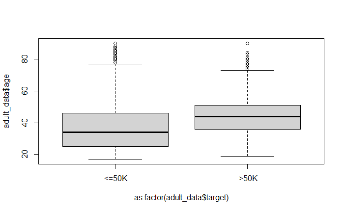

```r
  plot(adult_data$age~as.factor(adult_data$target))
```

```r
  t.test(adult_data$age~adult_data$target)
```

```
    Welch Two Sample t-test

data:  adult_data$age by adult_data$target
t = -50.264, df = 17411, p-value < 2.2e-16
alternative hypothesis: true difference in means between group  <=50K and group  >50K is not equal to 0
95 percent confidence interval:
 -7.757250 -7.174955
sample estimates:
mean in group  <=50K  mean in group  >50K
            36.78374             44.24984
```

- workclass: mosaic plot and chi-square test - is associated
  - the mosaic plot shows that there are 4 values that were more likely to have > 50k income; federal, local-gov, self-employed-inc, and self-employed-no-inc. There was also one, private, that was less likely to have income > 50k. It also showed that Private had the most observations.
  - the chisq test showed that the p-value was < 2.2e-16 but gave a warning that the approximation may be incorrect so I also ran it with simulate.p.value = TRUE and the p-value was still 0.0004998 which is lower than 0.05 so we can reject the null hypothesis. This supports the mosaic plot and the variables are associated.

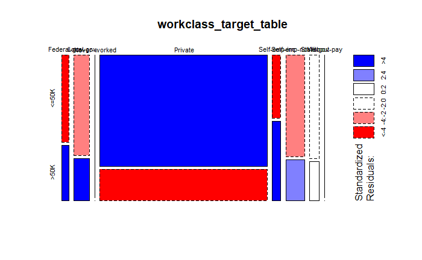

```r
  workclass_target_table <- table(adult_data$workclass, adult_data$target)
  mosaicplot(workclass_target_table, shade = TRUE)
```

```r
  chisq.test(workclass_target_table)
```

```
Warning: Chi-squared approximation may be incorrect
```

```
    Pearson's Chi-squared test

data:  workclass_target_table
X-squared = 827.72, df = 7, p-value < 2.2e-16
```

```r
  chisq.test(workclass_target_table, simulate.p.value = TRUE)
```

```
    Pearson's Chi-squared test with simulated p-value (based on 2000 replicates)

data:  workclass_target_table
X-squared = 827.72, df = NA, p-value = 0.0004998
```

- fnlwgt: side by side box plots and t-test - not associated
  - the side by side box plots showed almost the exact same distributions which shows no association likely.
  - the t-test confirms this and returns a value of .08 which is > .05 so we should not reject the null hypothesis.

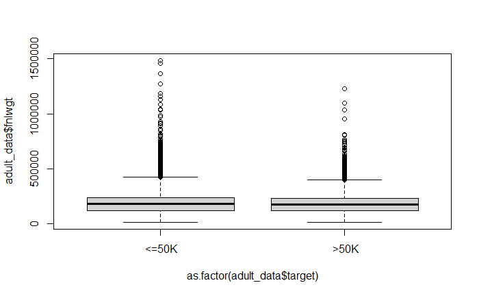

```r
  plot(adult_data$fnlwgt~as.factor(adult_data$target))
```

```r
  t.test(adult_data$fnlwgt~adult_data$target)
```

```
    Welch Two Sample t-test

data:  adult_data$fnlwgt by adult_data$target
t = 1.7412, df = 13615, p-value = 0.08167
alternative hypothesis: true difference in means between group  <=50K and group  >50K is not equal to 0
95 percent confidence interval:
 -293.7029 4965.4332
sample estimates:
mean in group  <=50K  mean in group  >50K
            190340.9             188005.0
```

- education: mosaic plot and chisq test - is associated
  - the mosaic plot shows that there are a lot of values that were less likely to make over 50K. There are also 4 values (Bachelors, Doctorate, Masters, and Prof-School) that are more likely to make over 50K
  - the chisq test evaluated a p-value that was smaller than 2.2e-16 without a warning so we can reject the null hypothesis

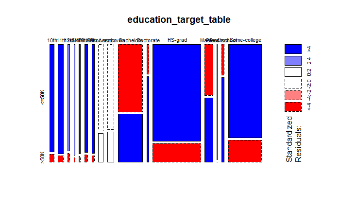

```r
  education_target_table <- table(adult_data$education, adult_data$target)
  mosaicplot(education_target_table, shade = TRUE)
```

```r
  chisq.test(education_target_table)
```

```
    Pearson's Chi-squared test

data:  education_target_table
X-squared = 4429.7, df = 15, p-value < 2.2e-16
```

- education-num: side by side box plots and t-test - associated
  - the side by side box plots shows little overlap and so the variables are likely associated
  - the t-test confirms this and returns a value < 2.2e-16 so we can reject the null hypothesis

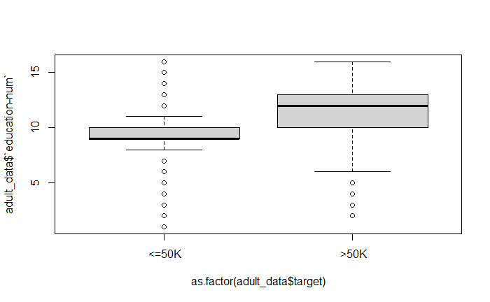

```r
  plot(adult_data$`education-num`~as.factor(adult_data$target))
```

```r
  t.test(adult_data$`education-num`~adult_data$target)
```

```
    Welch Two Sample t-test

data:  adult_data$`education-num` by adult_data$target
t = -64.896, df = 13421, p-value < 2.2e-16
alternative hypothesis: true difference in means between group  <=50K and group  >50K is not equal to 0
95 percent confidence interval:
 -2.077502 -1.955682
sample estimates:
mean in group  <=50K  mean in group  >50K
            9.595065            11.611657
```

- marital-status: mosaic plot and chisq test - is associated
  - the mosaic plot shows that every value but Married-civ-spouse and Married-AF-spouse is more likely to earn less than 50K. Married-AF-spouse shows not much difference and Married-civ-spouse is more likely to make more than 50K. Variable is more than likely associated
  - the chisq test confirms this with a p-value less than 2.2e-16 so null hypothesis can be rejected

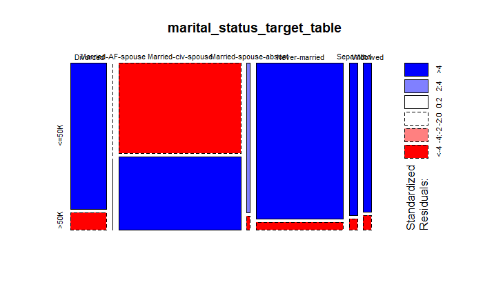

```r
  marital_status_target_table <- table(adult_data$`marital-status`, adult_data$target)
  mosaicplot(marital_status_target_table, shade = TRUE)
```

```r
  chisq.test(marital_status_target_table)
```

```
    Pearson's Chi-squared test

data:  marital_status_target_table
X-squared = 6517.7, df = 6, p-value < 2.2e-16
```

- occupation: mosaic plot and chisq test - is associated
  - the mosaic plot shows a lot of blue and red which means that there are a lot of variables that show more or less frequent than the expected cell frequency which eludes to the variable being associated
  - the chisq test shows that the p-value is less than 2.2e-16 although there is a warning. Setting simulate.p.value to true still produces a p-value less than .05 so we can reject the null hypothesis

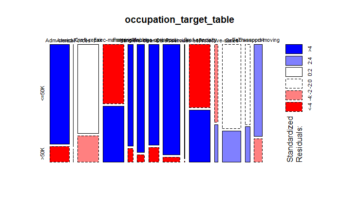

```r
  occupation_target_table <- table(adult_data$occupation, adult_data$target)
  mosaicplot(occupation_target_table, shade = TRUE)
```

```r
  chisq.test(occupation_target_table)
```

```
Warning: Chi-squared approximation may be incorrect
```

```
    Pearson's Chi-squared test

data:  occupation_target_table
X-squared = 3744.9, df = 13, p-value < 2.2e-16
```

```r
  chisq.test(occupation_target_table, simulate.p.value = TRUE)
```

```
    Pearson's Chi-squared test with simulated p-value (based on 2000 replicates)

data:  occupation_target_table
X-squared = 3744.9, df = NA, p-value = 0.0004998
```

- relationship: mosaic plot and chisq test - is associated
  - the mosaic plot shows a strong likelihood that husbands and wives are more likely to make more than 50K while all other values are less likely to make more than 50K and more likely to make less than 50K. Variables is most likely associated.
  - the chisq test confirms this and produces a p-value less than 2.2e-16 which means we can reject the null hypothesis

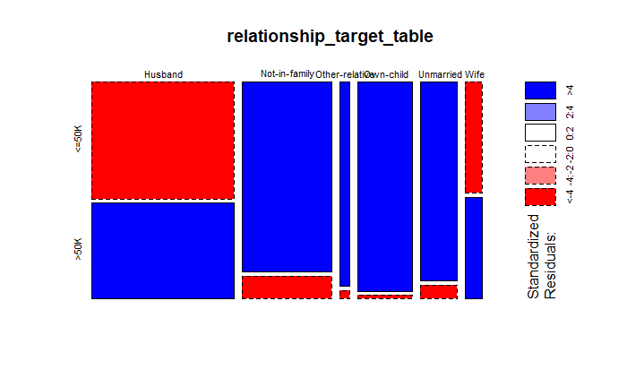

```r
  relationship_target_table <- table(adult_data$relationship, adult_data$target)
  mosaicplot(relationship_target_table, shade = TRUE)
```

```r
  chisq.test(relationship_target_table)
```

```
    Pearson's Chi-squared test

data:  relationship_target_table
X-squared = 6699.1, df = 5, p-value < 2.2e-16
```

- race: mosaic plot and chisq test - is associated
  - the mosaic plot shows a strong association between this and the target variable. If race value is White then those people are more likely to make over 50K and less likely to make less than 50K. At the same time all other values besides Asian-PAC-Islander are less likely to make over 50K and more likely to make less than 50K.Variables are more than likely associated.
  - the chisq test produces a p-value that is less than 2.2e-16 so we can reject the null hypothesis

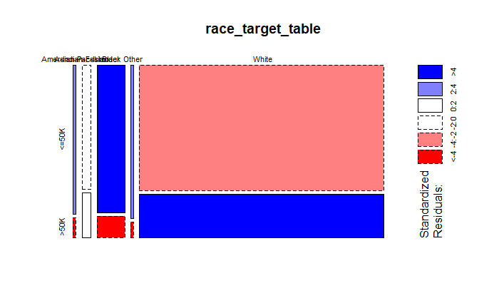

```r
  race_target_table <- table(adult_data$race, adult_data$target)
  mosaicplot(race_target_table, shade = TRUE)
```

```r
  chisq.test(race_target_table)
```

```
    Pearson's Chi-squared test

data:  race_target_table
X-squared = 330.92, df = 4, p-value < 2.2e-16
```

- sex: mosaic plot and chisq test - is associated
  - the mosaic plot shows very strong likelihood that the variables are associated as males are more likely to make more than 50K and less likely to make less than 50K while females are more likely to make less than 50K and less likely to make more than 50K.
  - the chisq test confirms this and produces a p-value that is less than .05 so the null hypothesis can be rejected

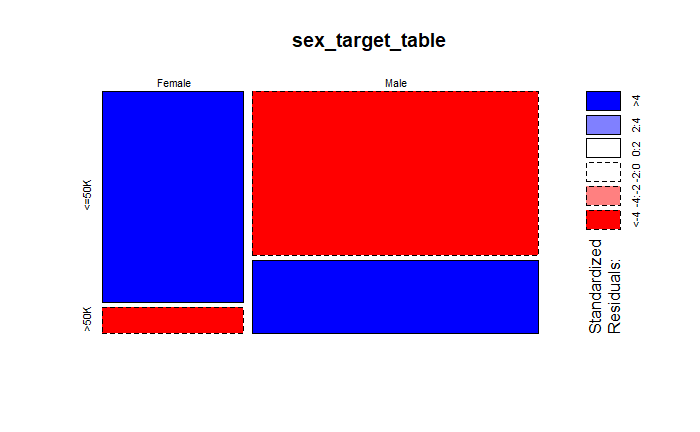

```r
  sex_target_table <- table(adult_data$sex, adult_data$target)
  mosaicplot(sex_target_table, shade = TRUE)
```

```r
  chisq.test(sex_target_table)
```

```
    Pearson's Chi-squared test with Yates' continuity correction

data:  sex_target_table
X-squared = 1517.8, df = 1, p-value < 2.2e-16
```

- capital-gain: side by side box plots and t-test - is associated
  - the side by side box plots is difficult to decipher
  - the t-test produces a p-value of less than .05 so we can reject the null hypothesis

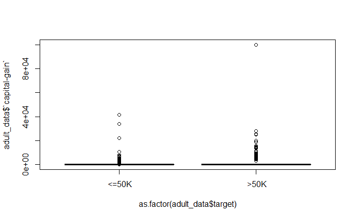

```r
  plot(adult_data$`capital-gain`~as.factor(adult_data$target))
```

```r
  t.test(adult_data$`capital-gain`~adult_data$target)
```

```
    Welch Two Sample t-test

data:  adult_data$`capital-gain` by adult_data$target
t = -23.427, df = 7861.7, p-value < 2.2e-16
alternative hypothesis: true difference in means between group  <=50K and group  >50K is not equal to 0
95 percent confidence interval:
 -4180.166 -3534.614
sample estimates:
mean in group  <=50K  mean in group  >50K
            148.7525            4006.1425
```

- capital-loss: side by side box plots and t-test - is associated
  - the side by side box plots is also difficult to decipher
  - the t-test produces a p-value of less than .05 so we can reject the null hypothesis

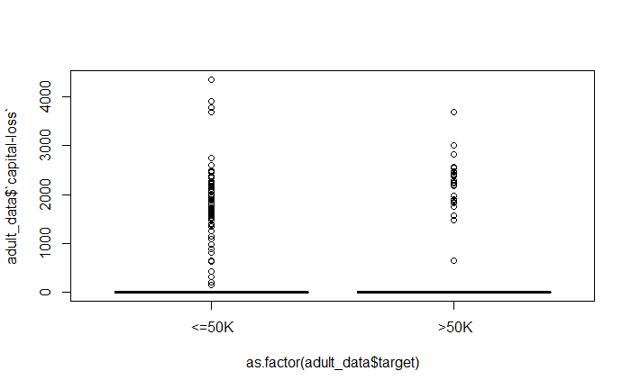

```r
  plot(adult_data$`capital-loss`~as.factor(adult_data$target))
```

```r
  t.test(adult_data$`capital-loss`~adult_data$target)
```

```
    Welch Two Sample t-test

data:  adult_data$`capital-loss` by adult_data$target
t = -20.238, df = 9231.1, p-value < 2.2e-16
alternative hypothesis: true difference in means between group  <=50K and group  >50K is not equal to 0
95 percent confidence interval:
 -155.5985 -128.1187
sample estimates:
mean in group  <=50K  mean in group  >50K
            53.14292            195.00153
```

- hours-per-week: side by side box plots and t-test - is associated
  - the side by side box plots show little overlap and so it is likely that the variables are associated
  - the t-test confirms this and produces a p-value of less than .05 so the null hypothesis can be rejected

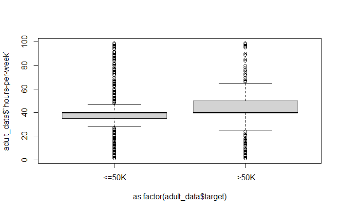

```r
  plot(adult_data$`hours-per-week`~as.factor(adult_data$target))
```

```r
  t.test(adult_data$`hours-per-week`~adult_data$target)
```

```
    Welch Two Sample t-test

data:  adult_data$`hours-per-week` by adult_data$target
t = -45.123, df = 14570, p-value < 2.2e-16
alternative hypothesis: true difference in means between group  <=50K and group  >50K is not equal to 0
95 percent confidence interval:
 -6.920943 -6.344690
sample estimates:
mean in group  <=50K  mean in group  >50K
            38.84021             45.47303
```

- native-country: mosaic plot and chisq test - is associated
  - the mosaic plot shows that there are a lot more observations of North_America(after combining values for data sparsity) than any other value. There are also two values (Europe and Asia) that are more likely to make more than 50K and one value (South_America) that is more likely to make less than 50K and less likely to make more than 50K
  - the chisq test produces a p-value that is less than .05 and so the null hypothesis can be rejected

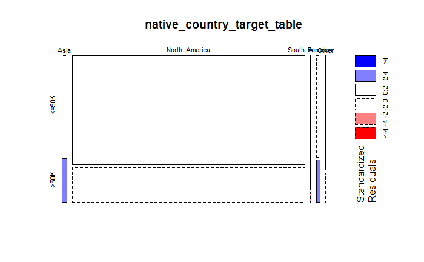

```r
  native_country_target_table <- table(adult_data$`native-country`, adult_data$target)
  mosaicplot(native_country_target_table, shade = TRUE)
```

```r
  chisq.test(native_country_target_table)
```

```
    Pearson's Chi-squared test

data:  native_country_target_table
X-squared = 41.234, df = 4, p-value = 2.404e-08
```

Summary: most variables are associated which makes me a little nervous but most of them were pretty conclusive. The following variables are the ones that are not associated and will be removed from testing and train data: fnlwgt

```r
  adult_train <- subset(adult_train, select = -c(fnlwgt))
  adult_test <- subset(adult_test, select = -c(fnlwgt))
```